```python
import google.datalab.bigquery as bq
from sklearn.cluster import AgglomerativeClustering
import numpy as np
from scipy.cluster.hierarchy import dendrogram, linkage
import matplotlib.pyplot as plt

print(__doc__)
from time import time
from scipy import ndimage
from sklearn import manifold, datasets
```

```
Automatically created module for IPython interactive environment
```

# Students entries August 2018, November 2018, February 2019

## Read from Big Query

```python
sql = """
    SELECT
     *
    FROM
    `big-data-analytics-2.agnesDataset.student_bda`
"""
```

```python
df = bq.Query(sql).execute().result().to_dataframe()
```

```python
df
```

[output not shown]

# AGNES

```python
X = np.array(df)
X
```

[output not shown]

```python
n_clusters=3
#distance= 'euclidean'
distance= 'cosine'
linkage_method='complete'
```

=> linkage : {“ward”, “complete”, “average”, “single”}, optional (default=”ward”) Which linkage criterion to use. The linkage criterion determines which distance to use between sets of observation. The algorithm will merge the pairs of cluster that minimize this criterion.

- ward minimizes the variance of the clusters being merged.
- average uses the average of the distances of each observation of the two sets.
- complete or maximum linkage uses the maximum distances between all observations of the two sets.
- single uses the minimum of the distances between all observations of the two sets.

=> n_clusters : The number of clusters to find.

=> affinity : Metric used to compute the linkage. Can be “euclidean”, “l1”, “l2”, “manhattan”, “cosine”, or ‘precomputed’. If linkage is “ward”, only “euclidean” is accepted.

=> memory : cache the output of the computation of the tree.(Optional)

=> connectivity: connectivity matrix as kneighbors_graph, the hierarchical clustering algorithm is unstructured.(Optional)

=> compute_full_tree : bool or ‘auto’ (optional) Stop early the construction of the tree at n_clusters. This is useful to decrease computation, useful only when specifying connectivity matrix and caching, it may be advantageous to compute the full tree.

pooling_func : callable, default=’deprecated’ Ignored.

```python
AgglomerativeClustering(affinity=distance, compute_full_tree='auto',
            connectivity=None, linkage=linkage_method, memory=None, n_clusters=n_clusters,
            pooling_func='deprecated')
```

```
AgglomerativeClustering(affinity='cosine', compute_full_tree='auto',
            connectivity=None, linkage='complete', memory=None,
            n_clusters=3, pooling_func='deprecated')
```

## Attributes

```python
X = np.array(df)
```

```python
clustering = AgglomerativeClustering().fit(X)
```

cluster labels for each point

```python
y =clustering.labels_
y
```

```
array([0, 0, 0, 1, 0, 1, 1, 0, 0, 0, 0, 0, 0, 0, 0, 1, 1, 1, 1, 1, 1, 1,
       1])
```

Number of leaves in the hierarchical tree.

```python
clustering.n_leaves_
```

```
23
```

```python
def hierarchical_Clustering_Dendrogram (X, method, metric, xlabel):
  linkage_matrix = linkage(X, method, metric)
  figure = plt.figure(figsize=(7.5, 5))
  dendrogram(
      linkage_matrix,
      color_threshold=0,
      leaf_rotation=90.,  # rotates the x axis labels
      leaf_font_size=8.,
      truncate_mode='lastp', #show only the last p merged clusters
  )
  plt.title('Hierarchical Clustering Dendrogram '+method)
  plt.xlabel(xlabel)
  plt.ylabel('distance')
  plt.tight_layout()
  plt.show()
```

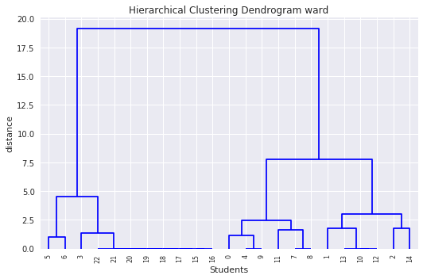

```python
hierarchical_Clustering_Dendrogram(X, 'ward', 'euclidean', 'Students')
```

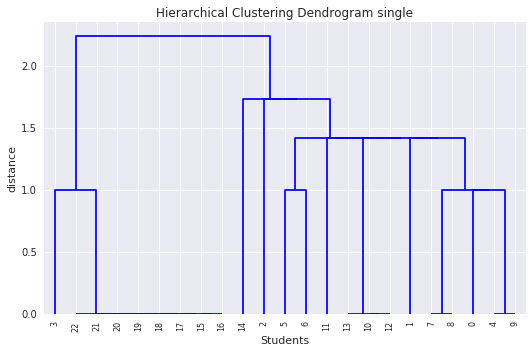

```python
hierarchical_Clustering_Dendrogram(X, 'single', 'euclidean', 'Students')
```

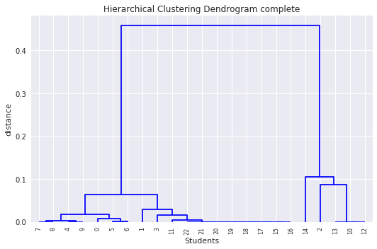

```python
hierarchical_Clustering_Dendrogram(X, 'complete', 'cosine', 'Students')
```

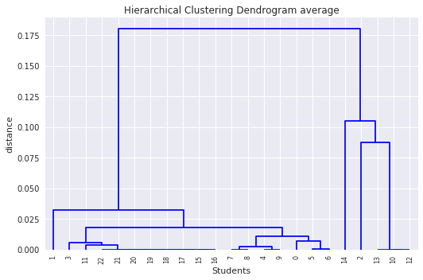

```python
hierarchical_Clustering_Dendrogram(X, 'average', 'cosine', 'Students')
```

[figure not shown]

```python
# Plot clustering results
n_clusters = 3
labels = ('Waveform 1')

model = AgglomerativeClustering(n_clusters=n_clusters,
                                    linkage="ward", affinity="euclidean")
model.fit(X)
plt.figure()
plt.axes([0, 0, 1, 1])
for l, c in zip(np.arange(model.n_clusters), 'rgbk'):
    plt.plot(X[model.labels_ == l].T, c=c, alpha=.5)
plt.axis('tight')
plt.axis('off')
plt.suptitle("AgglomerativeClustering(affinity = ward, linkage = euclidean)", size=20)
plt.show()
```

```python
model
```

```
AgglomerativeClustering(affinity='euclidean', compute_full_tree='auto',
            connectivity=None, linkage='ward', memory=None, n_clusters=3,
            pooling_func=<function mean at 0x7fdee67b4500>)
```

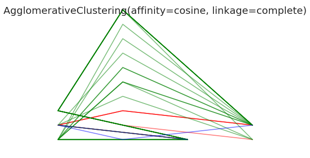

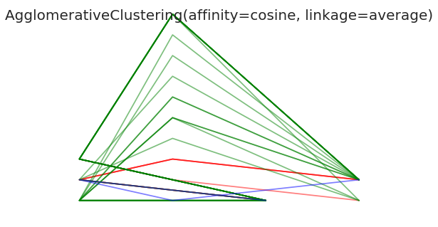

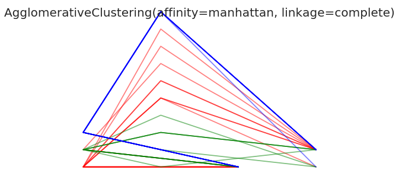

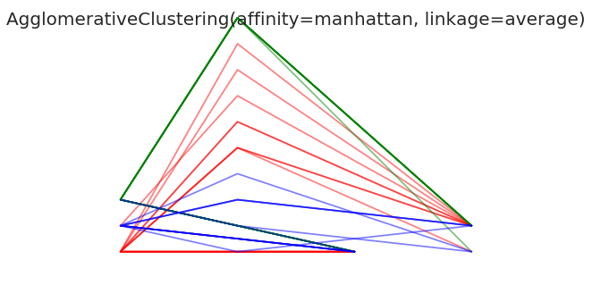

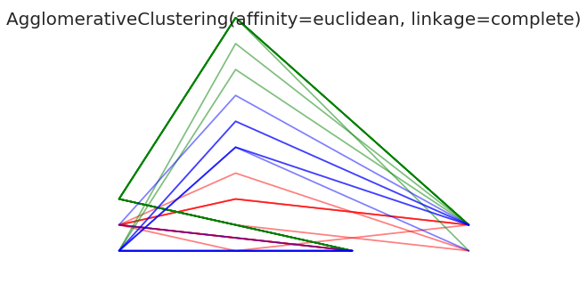

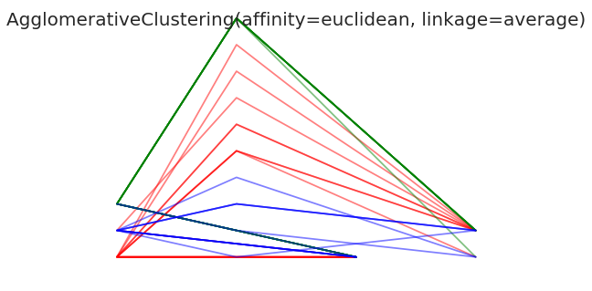

```python
# Plot clustering results
for index, metric in enumerate(["cosine", "manhattan", "euclidean"]):
    for index_1, linkageAgglomerative in enumerate(["complete", "average"]):
        model = AgglomerativeClustering(n_clusters=n_clusters,
                                    linkage=linkageAgglomerative, affinity=metric)
        model.fit(df)
        plt.figure()
        plt.axes([0, 0, 1, 1])
        for l, c in zip(np.arange(model.n_clusters), 'rgbk'):
            plt.plot(df[model.labels_ == l].T, c=c, alpha=.5)
        plt.axis('tight')
        plt.axis('off')
        plt.suptitle("AgglomerativeClustering(affinity=%s, linkage=%s)" % (metric, linkageAgglomerative), size=20)
    plt.show()
```